# regression_plots_salesperworker

2024-02-01

Regression details for reference:

- Standardized vars: “firm_age”, “num_employees”, “pcnt_owned_by_largest_owner”, “manager_experience_yrs”, “freq_meetings_tax_officials”
- Equation (or replace temp with climate var): lm(salesperworker ~ avg_temp + avg_temp:firm_age + avg_temp:size + avg_temp:sampling_region + avg_temp:pcnt_owned_by_largest_owner + avg_temp:manager_experience_yrs + avg_temp:top_manager_female + avg_temp:majority_national_sales + avg_temp:obstacle_electricity + avg_temp:obstacle_transport + avg_temp:obstacle_traderegulations + avg_temp:obstacle_businesslicensing + avg_temp:obstacle_accesstofinance + avg_temp:obstacle_laborregulations + avg_temp:insufficient_water_supply + avg_temp:checking_savings_account + avg_temp:overdraft_facility + avg_temp:financial_inst_credit + firm_age + size + sampling_region + pcnt_owned_by_largest_owner + manager_experience_yrs + top_manager_female + majority_national_sales + obstacle_electricity + obstacle_transport + obstacle_traderegulations + obstacle_businesslicensing + obstacle_accesstofinance + obstacle_laborregulations + insufficient_water_supply + checking_savings_account + overdraft_facility + financial_inst_credit, data = revenue_reg_data, weights = wt)

## Size

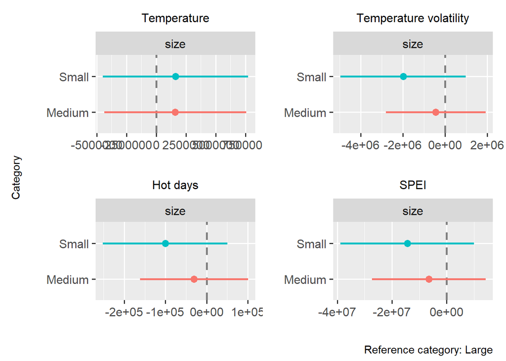

## Location

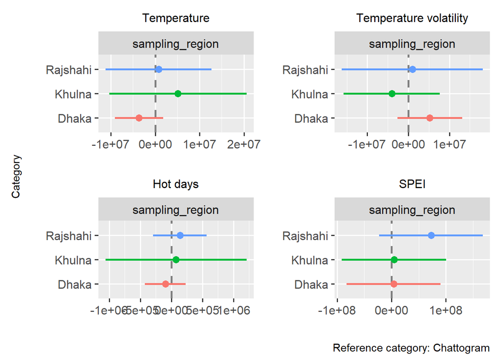

## Age & Pcnt owned by largest owner

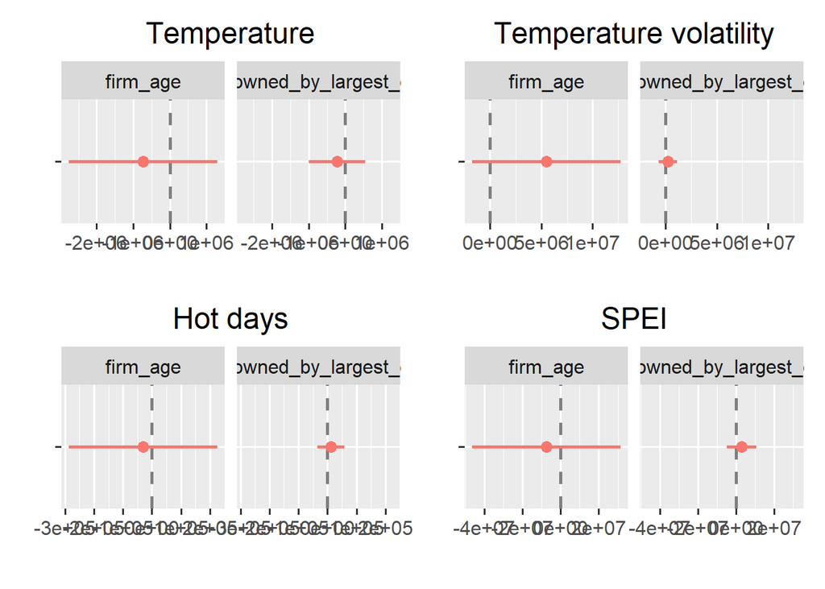

## Manager experience & Top manager female

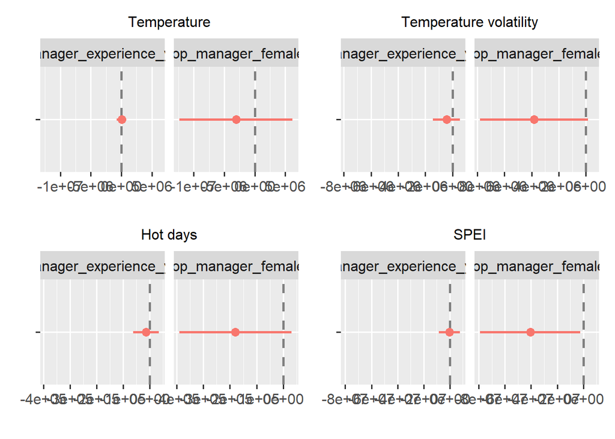

## Majority sales national

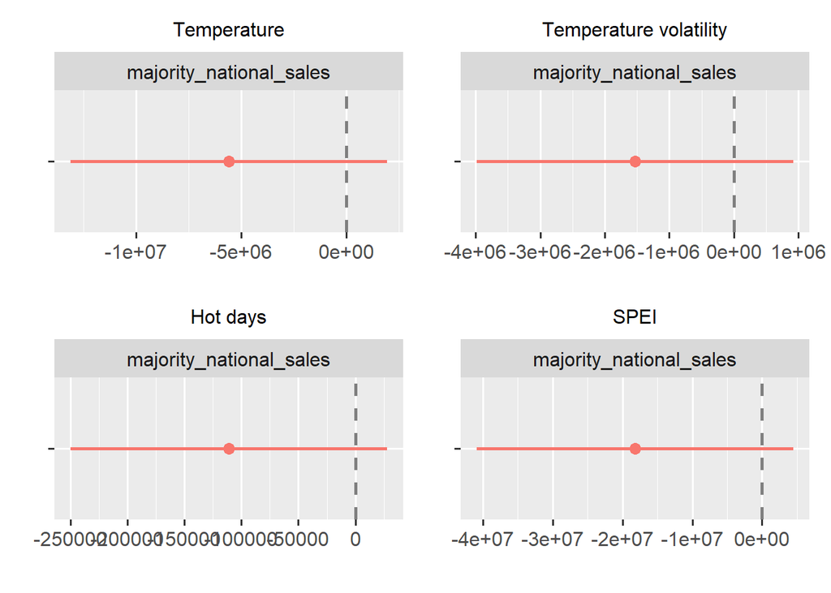

## Electricity - how much of an obstacle?

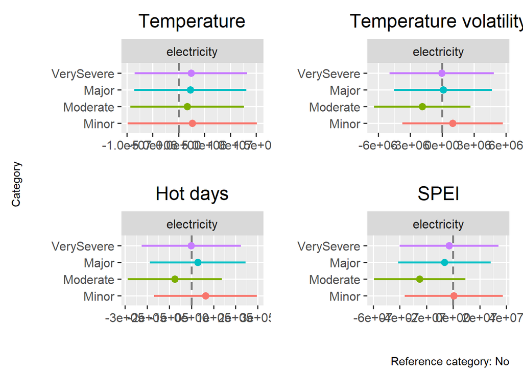

## Transport - how much of an obstacle?

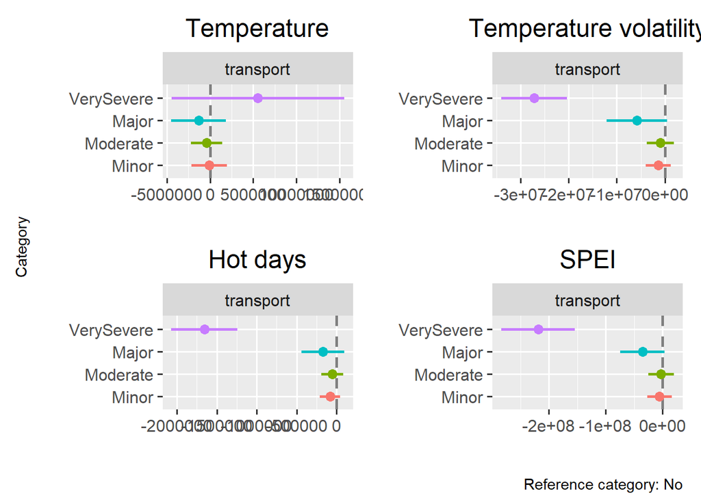

## Trade regulations - how much of an obstacle?

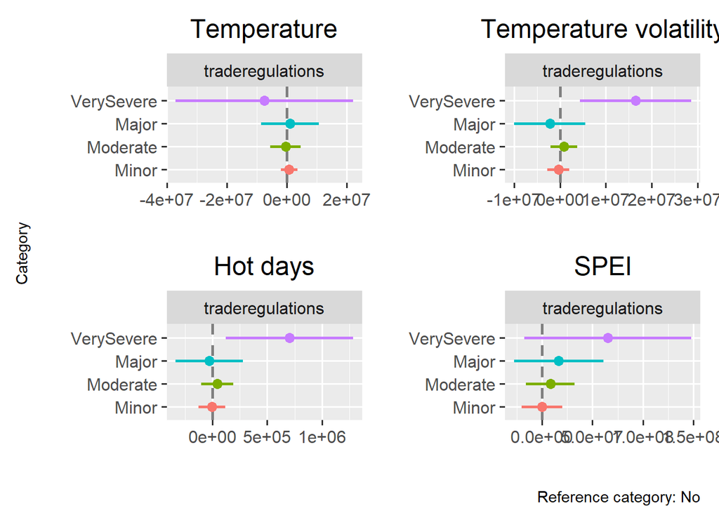

## Business licensing - how much of an obstacle?

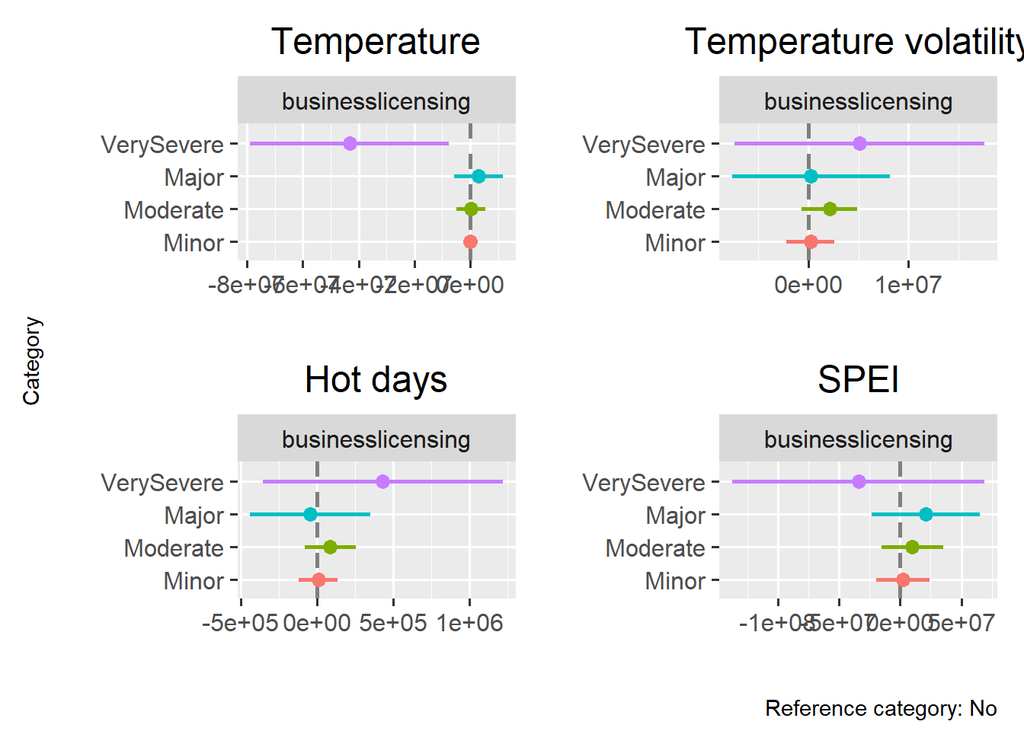

## Access to finance - how much of an obstacle?

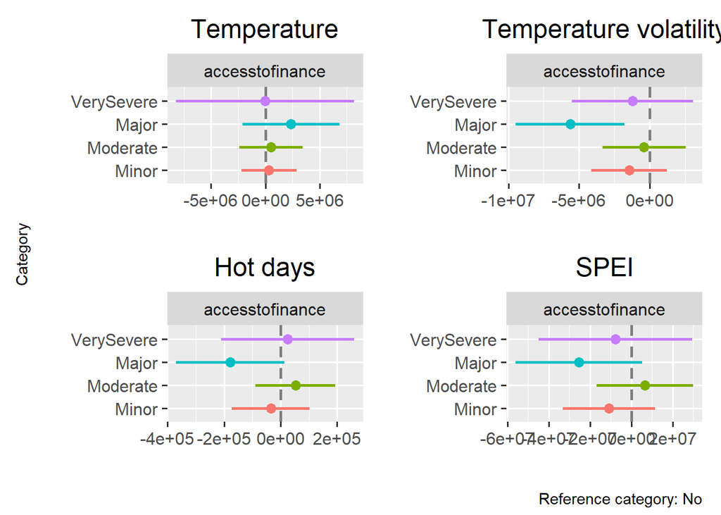

## Labor regulations - how much of an obstacle?

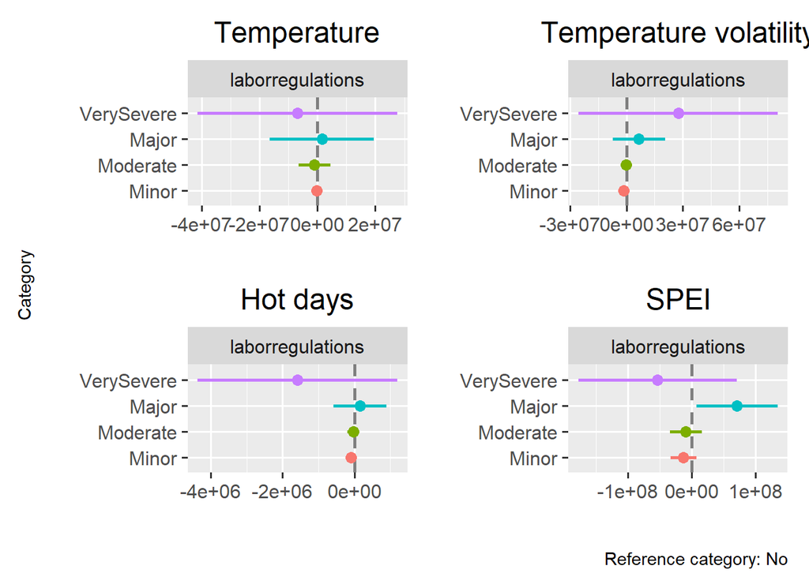

## Insufficient water supply

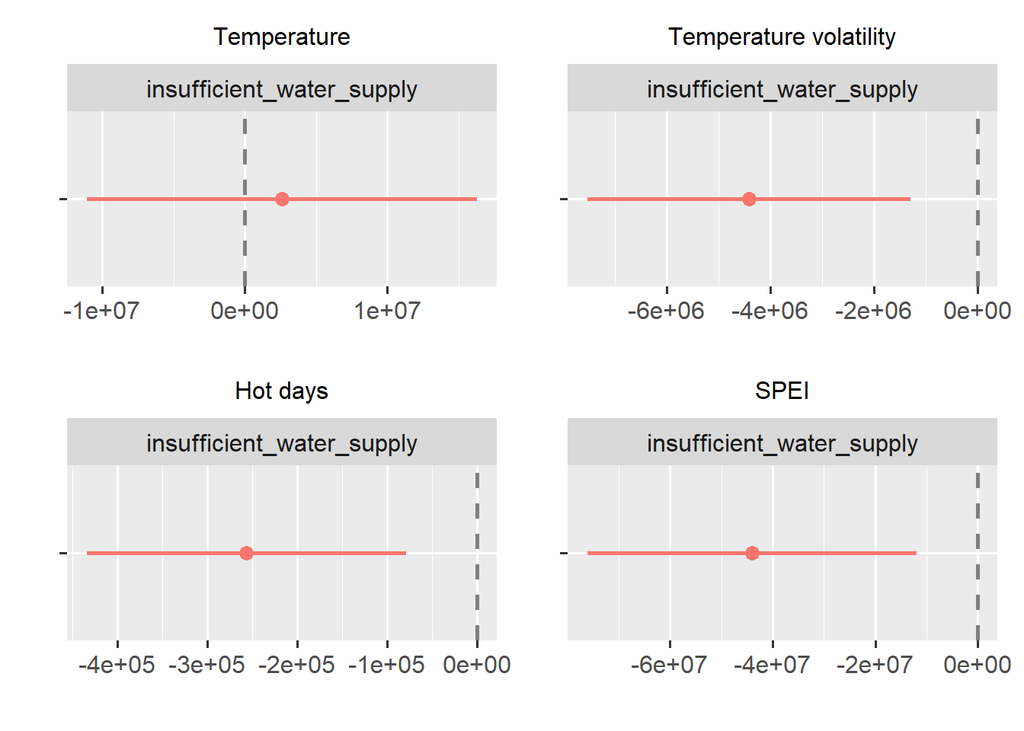

## Firm has checking/savings account

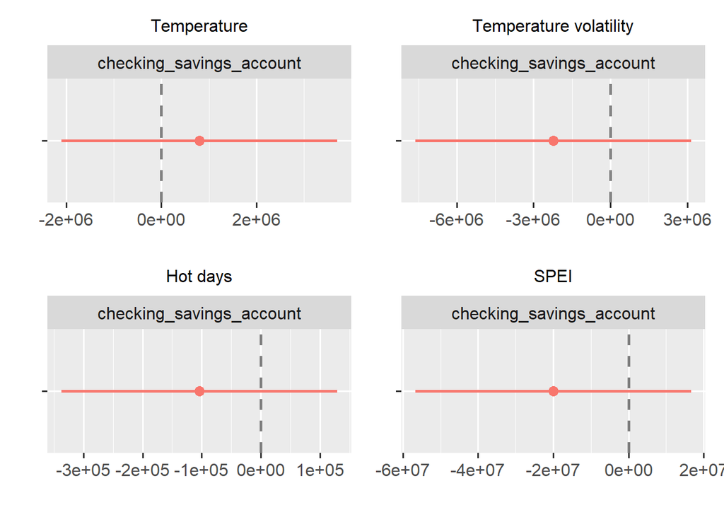

## Firm has credit/loan from financial institution / Firm has overdraft facility

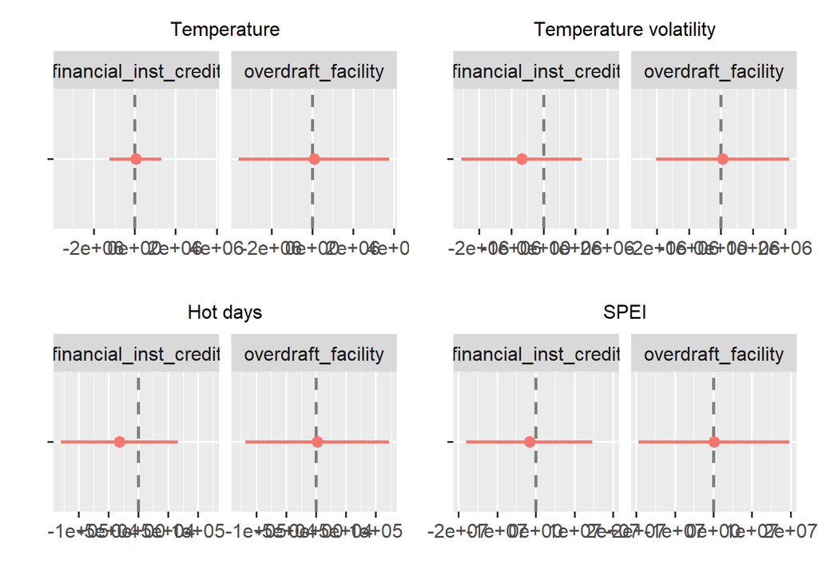